# Part A - 30 Marks - DOMAIN: Telecom

```python
import numpy as np
import pandas as pd
from sklearn.tree import DecisionTreeClassifier
import numpy as np
import pandas as pd
import seaborn as sns
from matplotlib import pyplot as plt
from sklearn.model_selection import train_test_split
from sklearn.tree import DecisionTreeClassifier
from sklearn import metrics
from sklearn.metrics import accuracy_score,f1_score,recall_score,precision_score, confusion_matrix
%matplotlib inline

from sklearn.feature_extraction.text import CountVectorizer
```

## 1. Data Understanding & Exploration: [5 Marks]

**A. Read ‘TelcomCustomer-Churn_1.csv’ as a DataFrame and assign it to a variable. [1 Mark]**

```python
import pandas as pd
Tel1=pd.read_csv('D:\\Great Learning\\Ensemble techniques\\TelcomCustomer-Churn_1.csv')
Tel1
```

|  | customerID | gender | SeniorCitizen | Partner | Dependents | tenure | PhoneService | MultipleLines | InternetService | OnlineSecurity |
| --- | --- | --- | --- | --- | --- | --- | --- | --- | --- | --- |
| 0 | 7590-VHVEG | Female | 0 | Yes | No | 1 | No | No phone service | DSL | No |
| 1 | 5575-GNVDE | Male | 0 | No | No | 34 | Yes | No | DSL | Yes |
| 2 | 3668-QPYBK | Male | 0 | No | No | 2 | Yes | No | DSL | Yes |
| 3 | 7795-CFOCW | Male | 0 | No | No | 45 | No | No phone service | DSL | Yes |
| 4 | 9237-HQITU | Female | 0 | No | No | 2 | Yes | No | Fiber optic | No |
| ... | ... | ... | ... | ... | ... | ... | ... | ... | ... | ... |
| 7038 | 6840-RESVB | Male | 0 | Yes | Yes | 24 | Yes | Yes | DSL | Yes |
| 7039 | 2234-XADUH | Female | 0 | Yes | Yes | 72 | Yes | Yes | Fiber optic | No |
| 7040 | 4801-JZAZL | Female | 0 | Yes | Yes | 11 | No | No phone service | DSL | Yes |
| 7041 | 8361-LTMKD | Male | 1 | Yes | No | 4 | Yes | Yes | Fiber optic | No |
| 7042 | 3186-AJIEK | Male | 0 | No | No | 66 | Yes | No | Fiber optic | Yes |

7043 rows × 10 columns

**B. Read ‘TelcomCustomer-Churn_2.csv’ as a DataFrame and assign it to a variable. [1 Mark]**

```python
Tel2=pd.read_csv('D:\\Great Learning\\Ensemble techniques\\TelcomCustomer-Churn_2.csv')
Tel2
```

|  | customerID | OnlineBackup | DeviceProtection | TechSupport | StreamingTV | StreamingMovies | Contract | PaperlessBilling | PaymentMethod | MonthlyCharges | TotalCharges | Churn |
| --- | --- | --- | --- | --- | --- | --- | --- | --- | --- | --- | --- | --- |
| 0 | 7590-VHVEG | Yes | No | No | No | No | Month-to-month | Yes | Electronic check | 29.85 | 29.85 | No |
| 1 | 5575-GNVDE | No | Yes | No | No | No | One year | No | Mailed check | 56.95 | 1889.5 | No |
| 2 | 3668-QPYBK | Yes | No | No | No | No | Month-to-month | Yes | Mailed check | 53.85 | 108.15 | Yes |
| 3 | 7795-CFOCW | No | Yes | Yes | No | No | One year | No | Bank transfer (automatic) | 42.30 | 1840.75 | No |
| 4 | 9237-HQITU | No | No | No | No | No | Month-to-month | Yes | Electronic check | 70.70 | 151.65 | Yes |
| ... | ... | ... | ... | ... | ... | ... | ... | ... | ... | ... | ... | ... |
| 7038 | 6840-RESVB | No | Yes | Yes | Yes | Yes | One year | Yes | Mailed check | 84.80 | 1990.5 | No |
| 7039 | 2234-XADUH | Yes | Yes | No | Yes | Yes | One year | Yes | Credit card (automatic) | 103.20 | 7362.9 | No |
| 7040 | 4801-JZAZL | No | No | No | No | No | Month-to-month | Yes | Electronic check | 29.60 | 346.45 | No |
| 7041 | 8361-LTMKD | No | No | No | No | No | Month-to-month | Yes | Mailed check | 74.40 | 306.6 | Yes |
| 7042 | 3186-AJIEK | No | Yes | Yes | Yes | Yes | Two year | Yes | Bank transfer (automatic) | 105.65 | 6844.5 | No |

7043 rows × 12 columns

**C. Merge both the DataFrames on key ‘customerID’ to form a single DataFrame [2 Mark]**

```python
Tel=pd.merge(Tel1, Tel2, on=['customerID'])
Tel
```

|  | customerID | gender | SeniorCitizen | Partner | Dependents | tenure | PhoneService | MultipleLines | InternetService | OnlineSecurity | ... | DeviceProtection | TechSupport | StreamingTV | StreamingMovies | Contract | PaperlessBilling | PaymentMethod | MonthlyCharges | TotalCharges | Churn |
| --- | --- | --- | --- | --- | --- | --- | --- | --- | --- | --- | --- | --- | --- | --- | --- | --- | --- | --- | --- | --- | --- |
| 0 | 7590-VHVEG | Female | 0 | Yes | No | 1 | No | No phone service | DSL | No | ... | No | No | No | No | Month-to-month | Yes | Electronic check | 29.85 | 29.85 | No |
| 1 | 5575-GNVDE | Male | 0 | No | No | 34 | Yes | No | DSL | Yes | ... | Yes | No | No | No | One year | No | Mailed check | 56.95 | 1889.5 | No |
| 2 | 3668-QPYBK | Male | 0 | No | No | 2 | Yes | No | DSL | Yes | ... | No | No | No | No | Month-to-month | Yes | Mailed check | 53.85 | 108.15 | Yes |
| 3 | 7795-CFOCW | Male | 0 | No | No | 45 | No | No phone service | DSL | Yes | ... | Yes | Yes | No | No | One year | No | Bank transfer (automatic) | 42.30 | 1840.75 | No |
| 4 | 9237-HQITU | Female | 0 | No | No | 2 | Yes | No | Fiber optic | No | ... | No | No | No | No | Month-to-month | Yes | Electronic check | 70.70 | 151.65 | Yes |
| ... | ... | ... | ... | ... | ... | ... | ... | ... | ... | ... | ... | ... | ... | ... | ... | ... | ... | ... | ... | ... | ... |
| 7038 | 6840-RESVB | Male | 0 | Yes | Yes | 24 | Yes | Yes | DSL | Yes | ... | Yes | Yes | Yes | Yes | One year | Yes | Mailed check | 84.80 | 1990.5 | No |
| 7039 | 2234-XADUH | Female | 0 | Yes | Yes | 72 | Yes | Yes | Fiber optic | No | ... | Yes | No | Yes | Yes | One year | Yes | Credit card (automatic) | 103.20 | 7362.9 | No |
| 7040 | 4801-JZAZL | Female | 0 | Yes | Yes | 11 | No | No phone service | DSL | Yes | ... | No | No | No | No | Month-to-month | Yes | Electronic check | 29.60 | 346.45 | No |
| 7041 | 8361-LTMKD | Male | 1 | Yes | No | 4 | Yes | Yes | Fiber optic | No | ... | No | No | No | No | Month-to-month | Yes | Mailed check | 74.40 | 306.6 | Yes |
| 7042 | 3186-AJIEK | Male | 0 | No | No | 66 | Yes | No | Fiber optic | Yes | ... | Yes | Yes | Yes | Yes | Two year | Yes | Bank transfer (automatic) | 105.65 | 6844.5 | No |

7043 rows × 21 columns

**D. Verify if all the columns are incorporated in the merged DataFrame by using simple comparison Operator in Python. [1 Marks]**

```python
Tel1.keys()
```

```
Index(['customerID', 'gender', 'SeniorCitizen', 'Partner', 'Dependents',
       'tenure', 'PhoneService', 'MultipleLines', 'InternetService',
       'OnlineSecurity'],
      dtype='object')
```

```python
Tel2.keys()
```

```
Index(['customerID', 'OnlineBackup', 'DeviceProtection', 'TechSupport',
       'StreamingTV', 'StreamingMovies', 'Contract', 'PaperlessBilling',
       'PaymentMethod', 'MonthlyCharges', 'TotalCharges', 'Churn'],
      dtype='object')
```

```python
Tel.keys()
```

```
Index(['customerID', 'gender', 'SeniorCitizen', 'Partner', 'Dependents',
       'tenure', 'PhoneService', 'MultipleLines', 'InternetService',
       'OnlineSecurity', 'OnlineBackup', 'DeviceProtection', 'TechSupport',
       'StreamingTV', 'StreamingMovies', 'Contract', 'PaperlessBilling',
       'PaymentMethod', 'MonthlyCharges', 'TotalCharges', 'Churn'],
      dtype='object')
```

```python
Tel['customerID'].equals(Tel1['customerID'])
```

```
True
```

```python
Tel['customerID'].equals(Tel2['customerID'])
```

```
True
```

## 2. Data Cleaning & Analysis: [5 Marks]

**A. Impute missing/unexpected values in the DataFrame. [2 Marks]**

```python
Tel.isnull().sum()
```

```
customerID          0
gender              0
SeniorCitizen       0
Partner             0
Dependents          0
tenure              0
PhoneService        0
MultipleLines       0
InternetService     0
OnlineSecurity      0
OnlineBackup        0
DeviceProtection    0
TechSupport         0
StreamingTV         0
StreamingMovies     0
Contract            0
PaperlessBilling    0
PaymentMethod       0
MonthlyCharges      0
TotalCharges        0
Churn               0
dtype: int64
```

```python
Tel.isnull().values.any()
```

```
False
```

**B. Make sure all the variables with continuous values are of ‘Float’ type. [2 Marks] [For Example: MonthlyCharges, TotalCharges]**

```python
Tel.dtypes
```

```
customerID           object
gender               object
SeniorCitizen         int64
Partner              object
Dependents           object
tenure                int64
PhoneService         object
MultipleLines        object
InternetService      object
OnlineSecurity       object
OnlineBackup         object
DeviceProtection     object
TechSupport          object
StreamingTV          object
StreamingMovies      object
Contract             object
PaperlessBilling     object
PaymentMethod        object
MonthlyCharges      float64
TotalCharges         object
Churn                object
dtype: object
```

```python
Tel["TotalCharges"] = pd.to_numeric(Tel["TotalCharges"],errors='coerce')
Tel.dtypes
```

```
customerID           object
gender               object
SeniorCitizen         int64
Partner              object
Dependents           object
tenure                int64
PhoneService         object
MultipleLines        object
InternetService      object
OnlineSecurity       object
OnlineBackup         object
DeviceProtection     object
TechSupport          object
StreamingTV          object
StreamingMovies      object
Contract             object
PaperlessBilling     object
PaymentMethod        object
MonthlyCharges      float64
TotalCharges        float64
Churn                object
dtype: object
```

**C. Create a function that will accept a DataFrame as input and return pie-charts for all the appropriate Categorical features. Clearly show percentage distribution in the pie-chart. [4 Marks]**

```python
Tel._get_numeric_data().columns
```

```
Index(['SeniorCitizen', 'tenure', 'MonthlyCharges', 'TotalCharges'], dtype='object')
```

```python
def piechart():
 T=Tel.select_dtypes(exclude=['number'])
 T.dtypes
 list_str_obj_cols = T.columns[T.dtypes == "object"].tolist()
 for str_obj_col in list_str_obj_cols:
    T[str_obj_col] = T[str_obj_col].astype("category")
 import matplotlib.pyplot as plt
 fig = plt.figure(figsize=(15, 15))
 ax1 = plt.subplot2grid((4,4),(0,0))
 p1=Tel.groupby('gender').size().plot(kind='pie', autopct='%.2f',ylabel='gender',fontsize=7,labeldistance=.4)
 ax1.legend(loc='best',fontsize=7)
 ax1 = plt.subplot2grid((4,4),(0,1))
 p2=Tel.groupby('Partner').size().plot(kind='pie', autopct='%.2f',ylabel='Partner',fontsize=7,labeldistance=.4)
 ax1.legend(loc='best',fontsize=7)
 ax1 = plt.subplot2grid((4,4),(0,2))
 p3=T.groupby('Dependents').size().plot(kind='pie', autopct='%.2f',ylabel='Dependents',fontsize=7,labeldistance=.4)
 ax1.legend(loc='best',fontsize=7)
 ax1 = plt.subplot2grid((4,4),(0,3))
 p4=T.groupby('PhoneService').size().plot(kind='pie', autopct='%.2f',ylabel='PhoneService',fontsize=7,labeldistance=.4)
 ax1.legend(loc='best',fontsize=7)
 ax1 = plt.subplot2grid((4,4),(1,0))
 p5=T.groupby('MultipleLines').size().plot(kind='pie', autopct='%.2f',ylabel='MultipleLines',fontsize=7,labeldistance=.2)
 ax1.legend(loc='best',fontsize=7)
 ax1 = plt.subplot2grid((4,4),(1,1))
 p6=T.groupby('InternetService').size().plot(kind='pie', autopct='%.2f',ylabel='InternetService',fontsize=7,labeldistance=.4)
 ax1.legend(loc='best',fontsize=7)
 ax1 = plt.subplot2grid((4,4),(1,2))
 p7=T.groupby('OnlineSecurity').size().plot(kind='pie', autopct='%.2f',ylabel='OnlineSecurity',fontsize=7,labeldistance=.4)
 ax1.legend(loc='best',fontsize=7)
 ax1 = plt.subplot2grid((4,4),(1,3))
 p8=T.groupby('OnlineBackup').size().plot(kind='pie', autopct='%.2f',ylabel='OnlineBackup',fontsize=7,labeldistance=.4)
 ax1.legend(loc='best',fontsize=7)
 ax1 = plt.subplot2grid((4,4),(2,0))
 p9=T.groupby('DeviceProtection').size().plot(kind='pie', autopct='%.2f',ylabel='DeviceProtection',fontsize=7,labeldistance=.4)
 ax1.legend(loc='best',fontsize=7)
 ax1 = plt.subplot2grid((4,4),(2,1))
 p10=T.groupby('TechSupport').size().plot(kind='pie', autopct='%.2f',ylabel='TechSupport',fontsize=7,labeldistance=.4)
 ax1.legend(loc='best',fontsize=7)
 ax1 = plt.subplot2grid((4,4),(2,2))
 p11=T.groupby('StreamingTV').size().plot(kind='pie', autopct='%.2f',ylabel='StreamingTV',fontsize=7,labeldistance=0.2)
 ax1.legend(loc='best',fontsize=7)
 ax1 = plt.subplot2grid((4,4),(2,3))
 p12=T.groupby('StreamingMovies').size().plot(kind='pie', autopct='%.2f',ylabel='StreamingMovies',fontsize=7,labeldistance=0.2)
 ax1.legend(loc='best',fontsize=7)
 ax1 = plt.subplot2grid((4,4),(3,0))
 p13=T.groupby('Contract').size().plot(kind='pie', autopct='%.2f',ylabel='Contract',fontsize=7,labeldistance=.4)
 ax1.legend(loc='best',fontsize=7)
 ax1 = plt.subplot2grid((4,4),(3,1))
 p14=T.groupby('PaperlessBilling').size().plot(kind='pie', autopct='%.2f',ylabel='PaperlessBilling',fontsize=7,labeldistance=.4)
 ax1.legend(loc='best',fontsize=7)
 ax1 = plt.subplot2grid((4,4),(3,2))
 p15=T.groupby('PaymentMethod').size().plot(kind='pie', autopct='%.2f',ylabel='PaymentMethod',fontsize=7,labeldistance=.4)
 ax1.legend(loc='best',fontsize=7)
 ax1 = plt.subplot2grid((4,4),(3,3))
 p16=T.groupby('Churn').size().plot(kind='pie', autopct='%.2f',ylabel='Churn',fontsize=7,labeldistance=.4)
 ax1.legend(loc='best',fontsize=7)
```

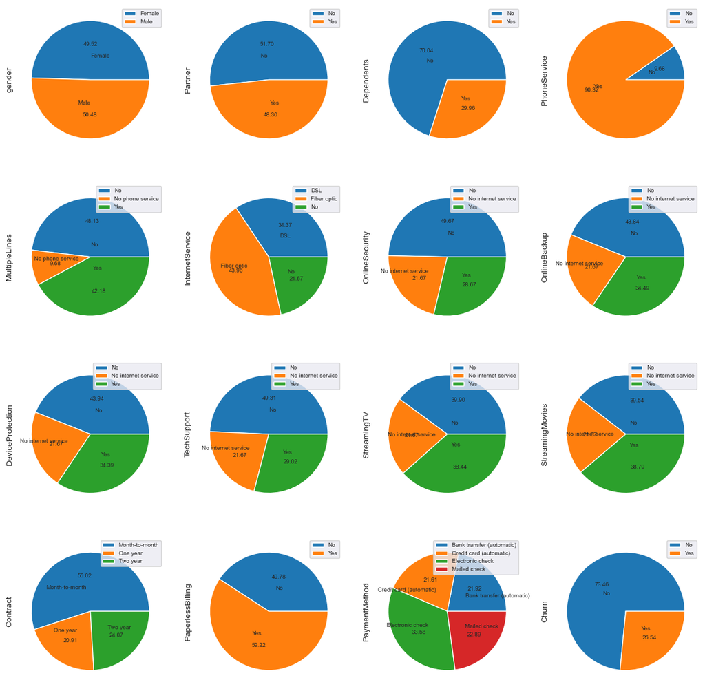

```python
piechart()
```

**D. Share insights for Q2.c. [2 Marks]**

*The pie chart gives the following insights:*  
The piechart for Churn gives the percentage of Customers who left within the last month. Only 26% of customers has left and 74% of them are still having the connection  
*Services that each customer has signed up for:*  
phone - 90% of customers use phone service and 9% use only for Internet  
multiple lines- Out of 90% customers who use phone service, 42% customers have multiple lines with or without internet service and 48% have one phone line only  
internet - Out of the people who use phone service 22% do not use internet service and 34% use DSL service and 44% use Fiberoptic service.Totally 78% of people use internet service  
online security - Out of 78% of Internet service using customers 28% opted for Online security and 50% did not opt for it  
online backup - Out of 78% of Internet service using customers 34% opted for Online backup and 44% did not opt for it  
device protection - Out of customers using service in all forms 34% opted for device protection and 44% did not opt for it  
tech support - Out of customers using service in all forms 29% opted for tech support and 49% did not opt for it  
streaming TV and movies - Out of 78% of Internet service using customers 39% opted for streaming TV and movies and 39% did not opt for it

**E. Encode all the appropriate Categorical features with the best suitable approach. [2 Marks]**

```python
from sklearn import preprocessing
le = preprocessing.LabelEncoder()
entel = pd.DataFrame()
object_col = Tel.columns[pd.Series(Tel.columns).apply(lambda x : Tel[x].dtype == 'O')]
for i in Tel.columns:
    if i in object_col:
        entel[i] = le.fit_transform(Tel[i])
    else:
        entel[i] = Tel[i]
```

```python
#entel =entel.drop(columns= ['customerID'])
entel.dtypes
```

```
customerID            int32
gender                int32
SeniorCitizen         int64
Partner               int32
Dependents            int32
tenure                int64
PhoneService          int32
MultipleLines         int32
InternetService       int32
OnlineSecurity        int32
OnlineBackup          int32
DeviceProtection      int32
TechSupport           int32
StreamingTV           int32
StreamingMovies       int32
Contract              int32
PaperlessBilling      int32
PaymentMethod         int32
MonthlyCharges      float64
TotalCharges        float64
Churn                 int32
dtype: object
```

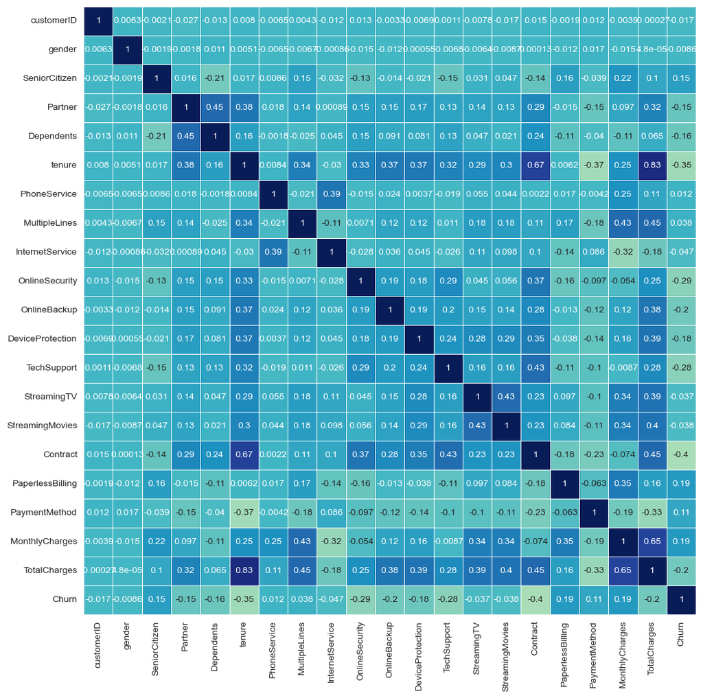

```python
plt.figure(figsize=(12,12))
sns.heatmap(entel.corr(),
            annot=True,
            linewidths=.5,
            center=0,
            cbar=False,
            cmap="YlGnBu")
plt.show()
```

**F. Split the data into 80% train and 20% test. [1 Marks]**

```python
X =entel.drop(columns= ['Churn','customerID'])
y = entel.Churn
X_train, X_test, y_train, y_test = train_test_split(X,y,test_size=0.2, random_state = 1)
```

```python
X
```

|  | gender | SeniorCitizen | Partner | Dependents | tenure | PhoneService | MultipleLines | InternetService | OnlineSecurity | OnlineBackup | DeviceProtection | TechSupport | StreamingTV | StreamingMovies | Contract | PaperlessBilling | PaymentMethod | MonthlyCharges | TotalCharges |
| --- | --- | --- | --- | --- | --- | --- | --- | --- | --- | --- | --- | --- | --- | --- | --- | --- | --- | --- | --- |
| 0 | 0 | 0 | 1 | 0 | 1 | 0 | 1 | 0 | 0 | 2 | 0 | 0 | 0 | 0 | 0 | 1 | 2 | 29.85 | 29.85 |
| 1 | 1 | 0 | 0 | 0 | 34 | 1 | 0 | 0 | 2 | 0 | 2 | 0 | 0 | 0 | 1 | 0 | 3 | 56.95 | 1889.50 |
| 2 | 1 | 0 | 0 | 0 | 2 | 1 | 0 | 0 | 2 | 2 | 0 | 0 | 0 | 0 | 0 | 1 | 3 | 53.85 | 108.15 |
| 3 | 1 | 0 | 0 | 0 | 45 | 0 | 1 | 0 | 2 | 0 | 2 | 2 | 0 | 0 | 1 | 0 | 0 | 42.30 | 1840.75 |
| 4 | 0 | 0 | 0 | 0 | 2 | 1 | 0 | 1 | 0 | 0 | 0 | 0 | 0 | 0 | 0 | 1 | 2 | 70.70 | 151.65 |
| ... | ... | ... | ... | ... | ... | ... | ... | ... | ... | ... | ... | ... | ... | ... | ... | ... | ... | ... | ... |
| 7038 | 1 | 0 | 1 | 1 | 24 | 1 | 2 | 0 | 2 | 0 | 2 | 2 | 2 | 2 | 1 | 1 | 3 | 84.80 | 1990.50 |
| 7039 | 0 | 0 | 1 | 1 | 72 | 1 | 2 | 1 | 0 | 2 | 2 | 0 | 2 | 2 | 1 | 1 | 1 | 103.20 | 7362.90 |
| 7040 | 0 | 0 | 1 | 1 | 11 | 0 | 1 | 0 | 2 | 0 | 0 | 0 | 0 | 0 | 0 | 1 | 2 | 29.60 | 346.45 |
| 7041 | 1 | 1 | 1 | 0 | 4 | 1 | 2 | 1 | 0 | 0 | 0 | 0 | 0 | 0 | 0 | 1 | 3 | 74.40 | 306.60 |
| 7042 | 1 | 0 | 0 | 0 | 66 | 1 | 0 | 1 | 2 | 0 | 2 | 2 | 2 | 2 | 2 | 1 | 0 | 105.65 | 6844.50 |

7043 rows × 19 columns

```python
y
```

```
0       0
1       0
2       1
3       0
4       1
       ..
7038    0
7039    0
7040    0
7041    1
7042    0
Name: Churn, Length: 7043, dtype: int32
```

**G. Normalize/Standardize the data with the best suitable approach. [2 Marks]**

**Min-Max Normalization**

```python
from sklearn.preprocessing import MinMaxScaler

min_max_scaler = MinMaxScaler().fit(entel)
entel_norm = min_max_scaler.transform(entel)
```

```python
(entel-entel.min())/(entel.max()-entel.min())
```

|  | customerID | gender | SeniorCitizen | Partner | Dependents | tenure | PhoneService | MultipleLines | InternetService | OnlineSecurity | ... | DeviceProtection | TechSupport | StreamingTV | StreamingMovies | Contract | PaperlessBilling | PaymentMethod | MonthlyCharges | TotalCharges | Churn |
| --- | --- | --- | --- | --- | --- | --- | --- | --- | --- | --- | --- | --- | --- | --- | --- | --- | --- | --- | --- | --- | --- |
| 0 | 0.763277 | 0.0 | 0.0 | 1.0 | 0.0 | 0.013889 | 0.0 | 0.5 | 0.0 | 0.0 | ... | 0.0 | 0.0 | 0.0 | 0.0 | 0.0 | 1.0 | 0.666667 | 0.115423 | 0.001275 | 0.0 |
| 1 | 0.562624 | 1.0 | 0.0 | 0.0 | 0.0 | 0.472222 | 1.0 | 0.0 | 0.0 | 1.0 | ... | 1.0 | 0.0 | 0.0 | 0.0 | 0.5 | 0.0 | 1.000000 | 0.385075 | 0.215867 | 0.0 |
| 2 | 0.364101 | 1.0 | 0.0 | 0.0 | 0.0 | 0.027778 | 1.0 | 0.0 | 0.0 | 1.0 | ... | 0.0 | 0.0 | 0.0 | 0.0 | 0.0 | 1.0 | 1.000000 | 0.354229 | 0.010310 | 1.0 |
| 3 | 0.785998 | 1.0 | 0.0 | 0.0 | 0.0 | 0.625000 | 0.0 | 0.5 | 0.0 | 1.0 | ... | 1.0 | 1.0 | 0.0 | 0.0 | 0.5 | 0.0 | 0.000000 | 0.239303 | 0.210241 | 0.0 |
| 4 | 0.924595 | 0.0 | 0.0 | 0.0 | 0.0 | 0.027778 | 1.0 | 0.0 | 0.5 | 0.0 | ... | 0.0 | 0.0 | 0.0 | 0.0 | 0.0 | 1.0 | 0.666667 | 0.521891 | 0.015330 | 1.0 |
| ... | ... | ... | ... | ... | ... | ... | ... | ... | ... | ... | ... | ... | ... | ... | ... | ... | ... | ... | ... | ... | ... |
| 7038 | 0.689151 | 1.0 | 0.0 | 1.0 | 1.0 | 0.333333 | 1.0 | 1.0 | 0.0 | 1.0 | ... | 1.0 | 1.0 | 1.0 | 1.0 | 0.5 | 1.0 | 1.000000 | 0.662189 | 0.227521 | 0.0 |
| 7039 | 0.216558 | 0.0 | 0.0 | 1.0 | 1.0 | 1.000000 | 1.0 | 1.0 | 0.5 | 0.0 | ... | 1.0 | 0.0 | 1.0 | 1.0 | 0.5 | 1.0 | 0.333333 | 0.845274 | 0.847461 | 0.0 |
| 7040 | 0.478131 | 0.0 | 0.0 | 1.0 | 1.0 | 0.152778 | 0.0 | 0.5 | 0.0 | 1.0 | ... | 0.0 | 0.0 | 0.0 | 0.0 | 0.0 | 1.0 | 0.666667 | 0.112935 | 0.037809 | 0.0 |
| 7041 | 0.842658 | 1.0 | 1.0 | 1.0 | 0.0 | 0.055556 | 1.0 | 1.0 | 0.5 | 0.0 | ... | 0.0 | 0.0 | 0.0 | 0.0 | 0.0 | 1.0 | 1.000000 | 0.558706 | 0.033210 | 1.0 |
| 7042 | 0.316103 | 1.0 | 0.0 | 0.0 | 0.0 | 0.916667 | 1.0 | 0.0 | 0.5 | 1.0 | ... | 1.0 | 1.0 | 1.0 | 1.0 | 1.0 | 1.0 | 0.000000 | 0.869652 | 0.787641 | 0.0 |

7043 rows × 21 columns

**Standardization**

```python
from sklearn.preprocessing import StandardScaler

scaler = StandardScaler().fit(entel)
entel_std = scaler.transform(entel)
entel_std
```

```
array([[ 0.91189045, -1.00955867, -0.43991649, ..., -1.16032292,
        -0.99419409, -0.60102348],
       [ 0.21690598,  0.99053183, -0.43991649, ..., -0.25962894,
        -0.17373982, -0.60102348],
       [-0.47070074,  0.99053183, -0.43991649, ..., -0.36266036,
        -0.95964911,  1.66382851],
       ...,
       [-0.07574495, -1.00955867, -0.43991649, ..., -1.1686319 ,
        -0.85451414, -0.60102348],
       [ 1.18683477,  0.99053183,  2.27315869, ...,  0.32033821,
        -0.87209546,  1.66382851],
       [-0.63694614,  0.99053183, -0.43991649, ...,  1.35896134,
         2.01234407, -0.60102348]])
```

## 3. Model building and Improvement: [10 Marks]

**A. Train a model using XGBoost. Also print best performing parameters along with train and test performance. [5 Marks]**

```python
pip install xgboost
```

```python
import xgboost as xg
xgb_r = xg.XGBRegressor(objective ='reg:logistic',
                  n_estimators = 10, seed = 123)

# Fitting the model
xgb_r.fit(X_train, y_train)

# Predict the model
pred = xgb_r.predict(X_test)
```

```python
from sklearn import metrics
from math import sqrt
from sklearn.model_selection import cross_validate
import time

from xgboost import XGBRegressor

def fit_n_print(model, X_train, X_test, y_train, y_test):  # take the model, train data and test data as input

    start = time.time()  # note the start time

    model.fit(X_train, y_train)   # fit the model using the train data

    pred = model.predict(X_test)     # model predictions on the test data

    r2 = metrics.r2_score(y_test, pred)  # calculate the r squared value on the test data

    rmse = sqrt(metrics.mean_squared_error(y_test, pred))   # Root mean squared error

    scorer = {'r2' : metrics.make_scorer(metrics.r2_score),
              'mse' : metrics.make_scorer(metrics.mean_squared_error),
                             }    # make scorers to be used in cross validation

    cv = cross_validate(model, X_train, y_train, cv=10, scoring = scorer)   # perform cross validation accross 3 metrics

    r2_cv = cv['test_r2'].mean()                                     # mean r squared value
    rmse_cv = np.mean([sqrt(mse) for mse in cv['test_mse']]) # mean RMSE value(take root of individual mse value and then mean)


    end = time.time()  #note the end time


    duration = end - start  # calculate the total duration


    return r2, rmse,  r2_cv, rmse_cv, duration, pred  # return all the metrics along with predictions
```

```python
result = fit_n_print(XGBRegressor(),X_train, X_test,y_train, y_test)
#print(result,['r2', 'rmse',  'r2_cv', 'rmse_cv', 'duration', 'pred' ])
result=list(result)
type(result)
print('R Squared:',result[0], '\nMSE:',result[1],  '\nR2 CV:', result[2],'\nRMSE CV:',result[3], '\nElapsed:',result[4],'\npred:',result[5])
```

```
R Squared: 0.2374945746988587
MSE: 0.37658046715568066
R2 CV: 0.1910787942011164
RMSE CV: 0.3985269947401921
Elapsed: 7.090997219085693
pred: [ 1.48125291e-01  3.35735977e-01  1.09001696e-01 ... -3.62489431e-04
  9.13567245e-02  7.58060336e-01]
```

**B. Improve performance of the XGBoost as much as possible. Also print best performing parameters along with train and test performance. [5 Marks]**

**Tuning the number of boosting rounds-Automated boosting round selection using early_stopping**

```python
Tel_dmatrix = xg.DMatrix(data=X, label=y)

# Create the parameter dictionary for each tree: params
params = {"objective":"reg:squarederror", "max_depth":4}

# Perform cross-validation with early-stopping: cv_results
cv_results = xg.cv(dtrain=Tel_dmatrix, nfold=3, params=params, metrics="rmse",
                    early_stopping_rounds=10, num_boost_round=20, as_pandas=True, seed=123)

# Print cv_results
print(cv_results)
```

```
   train-rmse-mean  train-rmse-std  test-rmse-mean  test-rmse-std
0         0.439423        0.001236        0.440770       0.000850
1         0.404561        0.001614        0.408405       0.001758
2         0.385145        0.001805        0.390472       0.002504
3         0.373339        0.001958        0.381139       0.002611
4         0.365486        0.002033        0.375819       0.002515
5         0.360430        0.002006        0.372647       0.002973
6         0.357027        0.001971        0.370896       0.003305
7         0.354637        0.001797        0.369970       0.003612
8         0.352488        0.001545        0.369575       0.003510
9         0.350898        0.001691        0.369224       0.003392
```

XGBoost's hyperparameters:  
Common tree tunable parameters  
*learning rate: learning rate/eta*  
*gamma: min loss reduction to create new tree split*  
*lambda: L2 regularization on leaf weights*  
*alpha: L1 regularization on leaf weights*  
*max_depth: max depth per tree*  
*subsample: % samples used per tree*  
*colsample_bytree: % features used per tree*

**Tuning learning rate - eta**

```python
eta_vals = [0.001, 0.01, 0.1,0.6]
best_rmse = []

# Systematicallyvary the eta
for curr_val in eta_vals:
    params['eta'] = curr_val

    # Perform cross-validation: cv_results
    cv_results = xg.cv(dtrain=Tel_dmatrix, params=params, nfold=3,
                        early_stopping_rounds=10, num_boost_round=20, metrics='rmse', seed=123,
                       as_pandas=True)

    # Append the final round rmse to best_rmse
    best_rmse.append(cv_results['test-rmse-mean'].tail().values[-1])

# Print the result DataFrame
print(pd.DataFrame(list(zip(eta_vals, best_rmse)), columns=['eta', 'best_rmse']))
```

```
     eta  best_rmse
0  0.001   0.495684
1  0.010   0.462452
2  0.100   0.371885
3  0.600   0.371525
```

**Tuning max_depth**

```python
max_depths = [1,2,3,4, 5, 10, 20]
best_rmse = []

for curr_val in max_depths:
    params['max_depth'] = curr_val

    # Perform cross-validation
    cv_results = xg.cv(dtrain=Tel_dmatrix, params=params, nfold=2,
                       early_stopping_rounds=10, num_boost_round=20, metrics='rmse', seed=123,
                        as_pandas=True)

    # Append the final round rmse to best_rmse
    best_rmse.append(cv_results['test-rmse-mean'].tail().values[-1])

# Print the result DataFrame
print(pd.DataFrame(list(zip(max_depths, best_rmse)), columns=['max_depth', 'best_rmse']))
```

```
   max_depth  best_rmse
0          1   0.375930
1          2   0.372606
2          3   0.371983
3          4   0.373305
4          5   0.374344
5         10   0.402633
6         20   0.421328
```

**Tuning using Grid search with XGBoost**

```python
from sklearn.model_selection import GridSearchCV

# Create the parameter grid: gbm_param_grid
gbm_param_grid = {
    'colsample_bytree': [0.3, 0.7],
    'n_estimators': [50,100],
    'max_depth': [2, 5],
    }

# Instantiate the regressor: gbm
gbm = xg.XGBRegressor()

# Perform grid search: grid_mse
grid_mse = GridSearchCV(param_grid=gbm_param_grid, estimator=gbm,
                        scoring='neg_mean_squared_error', cv=4, verbose=1)

# Fit grid_mse to the data
grid_mse.fit(X, y)

# Print the best parameters and lowest RMSE
print("Best parameters found: ", grid_mse.best_params_)
print("Lowest RMSE found: ", np.sqrt(np.abs(grid_mse.best_score_)))
```

```
Fitting 4 folds for each of 8 candidates, totalling 32 fits
Best parameters found:  {'colsample_bytree': 0.3, 'max_depth': 2, 'n_estimators': 50}
Lowest RMSE found:  0.3684767236009834
```

# Part B - 30 Marks - DOMAIN: IT

### Build a machine learning workflow that will run autonomously with the csv file and return best performing model

```python
pip install catboost
```

```python
pip install lightgbm
```

```python
import numpy as np
import pandas as pd
import matplotlib.pyplot as plt
import seaborn as sns
sns.set_style(style= 'darkgrid')

# pre-processing method
from sklearn.model_selection import train_test_split

# the regression models
from sklearn.linear_model import LinearRegression
from sklearn.tree import DecisionTreeRegressor
from sklearn.ensemble import BaggingRegressor
from sklearn.ensemble import RandomForestRegressor
from sklearn.ensemble import GradientBoostingRegressor
from xgboost import XGBRegressor
from catboost import CatBoostRegressor
from lightgbm import LGBMRegressor

# methods and classes for evaluation
from sklearn import metrics
from math import sqrt
from sklearn.model_selection import cross_validate
import time
```

### Create separate functions for various purposes.

**Preprocessing function**

```python
# Function to preprocess the data
def preprocess_data(path_to_csv,target_feature):
 #Read csv file
 global df
 df = pd.read_csv(path_to_csv)
 # Impute missing values (you can use loops and conditions imputing missing values
 print(df.isnull().sum())
 df.dropna(how='all')
 print(len(df.columns))
 #return(df)
```

```python
preprocess_data("D:\\Great Learning\\Ensemble techniques\\TelcomCustomer-Churn.csv",'Churn')
```

```
customerID          0
gender              0
SeniorCitizen       0
Partner             0
Dependents          0
tenure              0
PhoneService        0
MultipleLines       0
InternetService     0
OnlineSecurity      0
OnlineBackup        0
DeviceProtection    0
TechSupport         0
StreamingTV         0
StreamingMovies     0
Contract            0
PaperlessBilling    0
PaymentMethod       0
MonthlyCharges      0
TotalCharges        0
Churn               0
dtype: int64
21
```

**Analyse and Visualize Data**

```python
def analysedf():
 global df1,df2
 df1=df.drop(['customerID'], axis=1)
 print(df1.describe())
 df1["TotalCharges"] = pd.to_numeric(Tel["TotalCharges"],errors='coerce')

 #print("Data before encoding\n",df1.dtypes)

 from sklearn import preprocessing
 le = preprocessing.LabelEncoder()

 df2 = pd.DataFrame()
 object_col = df1.columns[pd.Series(df1.columns).apply(lambda x : df1[x].dtype == 'O')]
 for i in df1.columns:
    if i in object_col:
        df2[i] = le.fit_transform(df1[i])
    else:
        df2[i] = df1[i]
# print("Data after encoding\n",df2.dtypes)
 for i in df2.columns:
    if df2[i].dtype == 'O':
        df2[i] = df2[i].astype('category')
    else:
        pass
 df1.boxplot(column=['tenure'], by='Churn', grid=False, color='black')
 df1.boxplot(column=['MonthlyCharges'], by='Churn', grid=False, color='red')
 df1.boxplot(column=['TotalCharges'], by='Churn', grid=False, color='blue')
 plt.show()
```

```python
analysedf()
```

[output not shown]

```
       SeniorCitizen       tenure  MonthlyCharges
count    7043.000000  7043.000000     7043.000000
mean        0.162147    32.371149       64.761692
std         0.368612    24.559481       30.090047
min         0.000000     0.000000       18.250000
25%         0.000000     9.000000       35.500000
50%         0.000000    29.000000       70.350000
75%         0.000000    55.000000       89.850000
max         1.000000    72.000000      118.750000
```

**Pick and Split data for test and train**

```python
def pickXy():
 df2["TotalCharges"].fillna("0", inplace = True)
 global X,y,X_train, X_test, y_train, y_test
 X = df2.drop(columns= ['PaperlessBilling','PaymentMethod', 'Dependents','Churn'])
 y = df2.Churn
 print(X,y)
 X_train, X_test, y_train, y_test = train_test_split(X,y, random_state = 1)
```

```python
pickXy()
```

```
      gender  SeniorCitizen  Partner  tenure  PhoneService  MultipleLines  \
0          0              0        1       1             0              1
1          1              0        0      34             1              0
2          1              0        0       2             1              0
3          1              0        0      45             0              1
4          0              0        0       2             1              0
...      ...            ...      ...     ...           ...            ...
7038       1              0        1      24             1              2
7039       0              0        1      72             1              2
7040       0              0        1      11             0              1
7041       1              1        1       4             1              2
7042       1              0        0      66             1              0

      InternetService  OnlineSecurity  OnlineBackup  DeviceProtection  \
0                   0               0             2                 0
```

[output cut: 49 more lines]

**Fit data using various ensemble techniques**

```python
def fit_n_print(model, X_train, X_test, y_train, y_test):  # take the model, train data and test data as input
 global start,pred,r2, rmse, r2_cv, rmse_cv, duration, pred, scorer,cv, r2_cv,end, duration
 start = time.time()  # note the start time

 model.fit(X_train, y_train)   # fit the model using the train data

 pred = model.predict(X_test)     # model predictions on the test data

 r2 = metrics.r2_score(y_test, pred)  # calculate the r squared value on the test data

 rmse = sqrt(metrics.mean_squared_error(y_test, pred))   # Root mean squared error

 #rmsle = sqrt(metrics.mean_squared_log_error(y_test1, pred))  # Root mean squared log error (since the numbers are huge)

 scorer = {'r2' : metrics.make_scorer(metrics.r2_score),
              'mse' : metrics.make_scorer(metrics.mean_squared_error),
              #'msle' : metrics.make_scorer(metrics.mean_squared_log_error),
               }    # make scorers to be used in cross validation

 cv = cross_validate(model, X_train, y_train, cv=10, scoring = scorer)   # perform cross validation accross 3 metrics

 r2_cv = cv['test_r2'].mean()                                     # mean r squared value
 rmse_cv = np.mean([sqrt(mse) for mse in cv['test_mse']]) # mean RMSE value(take root of individual mse value and then mean)
 #rmsle_cv = np.mean([sqrt(msle) for msle in cv['test_msle']]) # mean RMSLE

 end = time.time()  #note the end time


 duration = end - start  # calculate the total duration


 return r2, rmse, r2_cv, rmse_cv, duration, pred  # return all the metrics along with predictions
```

```python
global fit_metrics
def fit_metrics():
 global result1,model
 from sklearn.linear_model import LinearRegression
 from sklearn.tree import DecisionTreeRegressor
 from sklearn.ensemble import BaggingRegressor
 from sklearn.ensemble import RandomForestRegressor
 from sklearn.ensemble import GradientBoostingRegressor
 from xgboost import XGBRegressor
 from catboost import CatBoostRegressor
 from lightgbm import LGBMRegressor

 # methods and classes for evaluation
 from sklearn import metrics
 from math import sqrt
 from sklearn.model_selection import cross_validate
 import time
 lr = LinearRegression()
 dt = DecisionTreeRegressor(random_state=1)
 br = BaggingRegressor(random_state=1)
 rf = RandomForestRegressor(random_state=1, n_estimators=100)  # specifying n_estimators to avoid "future warnings"
 gb = GradientBoostingRegressor(random_state=1, n_estimators=100)


 result = {}   # Create an empty dictionary to later use to store metrics of each of the models

# putting all 5 models in a for loop and appending the results of each of the models to the 'result' dictionary
 for model, name  in zip([lr, dt, br, rf, gb], ['Linear Regression', 'Decision Tree',
                                                    'Bagging Ensemble', 'Random Forest', 'Gradient Boost Ensemble']):
    result[name] = fit_n_print(model,X_train, X_test,y_train, y_test)
 result1 = pd.DataFrame(np.array(list(result.values()))[:,:-1],    # make a dataframe out of the metrics from result dictionary
                       columns= ['R Squared', 'MSE', 'R2 CV', 'RMSE CV', 'Elapsed'],
                      index= result.keys())   # use the model names as index

 result1.index.name = 'Model'   # name the index of the result1 dataframe as 'Model'

 print(result1)
```

```python
fit_metrics()
```

```
                        R Squared       MSE     R2 CV   RMSE CV    Elapsed
Model
Linear Regression        0.275845  0.366722  0.264466  0.381251   0.112603
Decision Tree           -0.414575  0.512547 -0.388689  0.523622   0.249988
Bagging Ensemble         0.177092  0.390928  0.164775  0.405987   1.350463
Random Forest            0.229783  0.378205  0.225927  0.390948  10.294473
Gradient Boost Ensemble  0.307988  0.358491  0.294226  0.373353   4.889485
```

```python
def main():
    preprocess_data("D:\\Great Learning\\Ensemble techniques\\TelcomCustomer-Churn.csv",'Churn')
    analysedf()
    pickXy()
    fit_n_print(model, X_train, X_test, y_train, y_test)
    fit_metrics()
```

```python
main()
```

```
customerID          0
gender              0
SeniorCitizen       0
Partner             0
Dependents          0
tenure              0
PhoneService        0
MultipleLines       0
InternetService     0
OnlineSecurity      0
OnlineBackup        0
DeviceProtection    0
TechSupport         0
StreamingTV         0
StreamingMovies     0
Contract            0
PaperlessBilling    0
PaymentMethod       0
MonthlyCharges      0
TotalCharges        0
Churn               0
dtype: int64
21
       SeniorCitizen       tenure  MonthlyCharges
count    7043.000000  7043.000000     7043.000000
mean        0.162147    32.371149       64.761692
std         0.368612    24.559481       30.090047
min         0.000000     0.000000       18.250000
25%         0.000000     9.000000       35.500000
50%         0.000000    29.000000       70.350000
75%         0.000000    55.000000       89.850000
max         1.000000    72.000000      118.750000
```

```
      gender  SeniorCitizen  Partner  tenure  PhoneService  MultipleLines  \
0          0              0        1       1             0              1
1          1              0        0      34             1              0
2          1              0        0       2             1              0
3          1              0        0      45             0              1
4          0              0        0       2             1              0
...      ...            ...      ...     ...           ...            ...
7038       1              0        1      24             1              2
7039       0              0        1      72             1              2
7040       0              0        1      11             0              1
7041       1              1        1       4             1              2
7042       1              0        0      66             1              0

      InternetService  OnlineSecurity  OnlineBackup  DeviceProtection  \
0                   0               0             2                 0
```

[output cut: 56 more lines]

```python
import dill as pickle
g = pickle.dumps(main)
```

```python
pickle.loads(g)()
```

```
customerID          0
gender              0
SeniorCitizen       0
Partner             0
Dependents          0
tenure              0
PhoneService        0
MultipleLines       0
InternetService     0
OnlineSecurity      0
OnlineBackup        0
DeviceProtection    0
TechSupport         0
StreamingTV         0
StreamingMovies     0
Contract            0
PaperlessBilling    0
PaymentMethod       0
MonthlyCharges      0
TotalCharges        0
Churn               0
dtype: int64
21
       SeniorCitizen       tenure  MonthlyCharges
count    7043.000000  7043.000000     7043.000000
mean        0.162147    32.371149       64.761692
std         0.368612    24.559481       30.090047
min         0.000000     0.000000       18.250000
25%         0.000000     9.000000       35.500000
50%         0.000000    29.000000       70.350000
75%         0.000000    55.000000       89.850000
max         1.000000    72.000000      118.750000
```

```
      gender  SeniorCitizen  Partner  tenure  PhoneService  MultipleLines  \
0          0              0        1       1             0              1
1          1              0        0      34             1              0
2          1              0        0       2             1              0
3          1              0        0      45             0              1
4          0              0        0       2             1              0
...      ...            ...      ...     ...           ...            ...
7038       1              0        1      24             1              2
7039       0              0        1      72             1              2
7040       0              0        1      11             0              1
7041       1              1        1       4             1              2
7042       1              0        0      66             1              0

      InternetService  OnlineSecurity  OnlineBackup  DeviceProtection  \
0                   0               0             2                 0
```

[output cut: 56 more lines]